# Chapter2

David Wang

June 1, 2016

## Undirected and Directed Graphs

Making an undirected graph object `g`. Plot `g` using the `plot()` function.

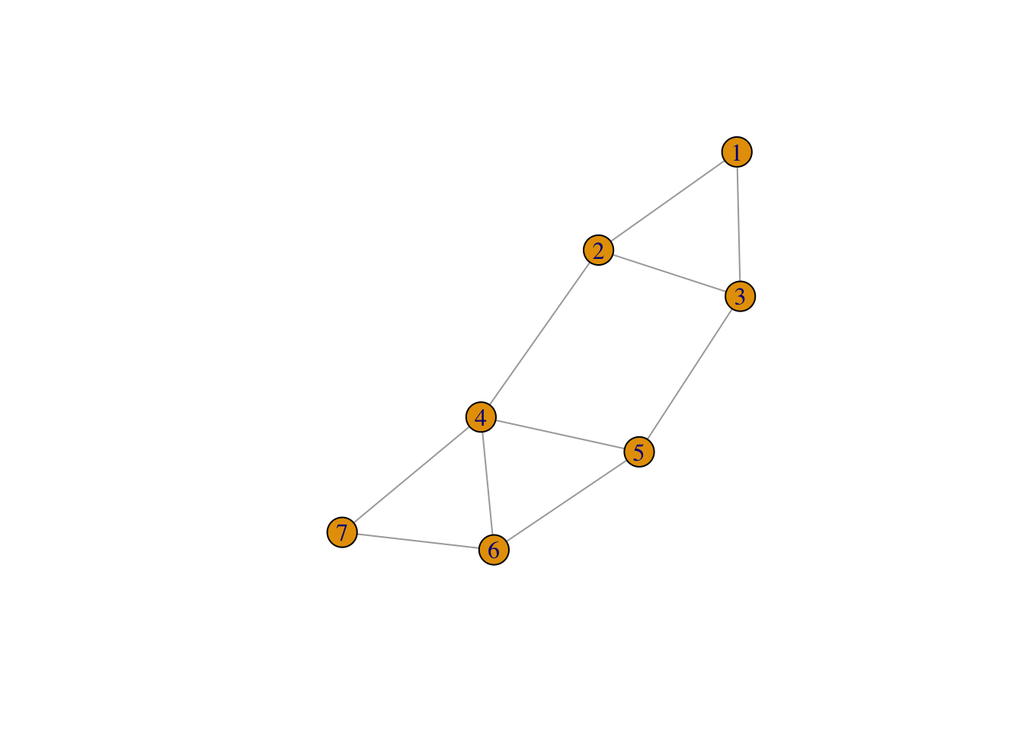

```r
g <- graph.formula( 1-2, 1-3, 2-3, 2-4, 3-5, 4-5, 4-6, 4-7, 5-6, 6-7)
plot(g)
```

Vertex sequence summary

```r
V(g)
```

```
## + 7/7 vertices, named:
## [1] 1 2 3 4 5 6 7
```

Edge sequence summary

```r
E(g)
```

```
## + 10/10 edges (vertex names):
##  [1] 1--2 1--3 2--3 2--4 3--5 4--5 4--6 4--7 5--6 6--7
```

Making a directed graph object `dg` and then plotting the construct.

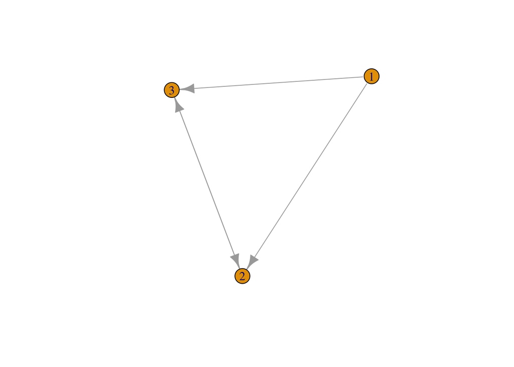

```r
dg <- graph.formula(1-+2, 1-+3, 2++3)
plot(dg)
```

Besides using numbers as labels, we are also able to generate custom labels explicitly:

```r
dg <- graph.formula(Sam-+Mary, Sam-+Tom, Mary++Tom)
str(dg)
```

```
## IGRAPH DN-- 3 4 --
## + attr: name (v/c)
## + edges (vertex names):
## [1] Sam ->Mary Sam ->Tom  Mary->Tom  Tom ->Mary
```

Another way to do the same thing would be to rename the vertices by assign the `$name` target to a vector of names:

```r
V(dg)$name <- c("Sam", "Mary", "Tom")
```

## Representations for Graphs

There are three basic formats of network data: adjacency lists, edge lists, and adjacency matrices.

Retrieve an edge list:

```r
E(dg)
```

```
## + 4/4 edges (vertex names):
## [1] Sam ->Mary Sam ->Tom  Mary->Tom  Tom ->Mary
```

Retrieve an adjacency matrix:

```r
get.adjacency(g)
```

```
## 7 x 7 sparse Matrix of class "dgCMatrix"
##   1 2 3 4 5 6 7
## 1 . 1 1 . . . .
## 2 1 . 1 1 . . .
## 3 1 1 . . 1 . .
## 4 . 1 . . 1 1 1
## 5 . . 1 1 . 1 .
## 6 . . . 1 1 . 1
## 7 . . . 1 . 1 .
```

Data already in these format can be directly analyzed with either `graph.adjacency`, `graph.edgelist`, or `graph.adjlist` depending on the data format. For data stored in a file, `read.graph` can be used and `write.graph` can be used to store graphs in various formats.

## Operations on Graphs

Induced subgraphs basically means that for a given subset of vertices selected, all of the edges in that subset will “come along” into the induced subgraph as well.

Creating induced subgraphs:

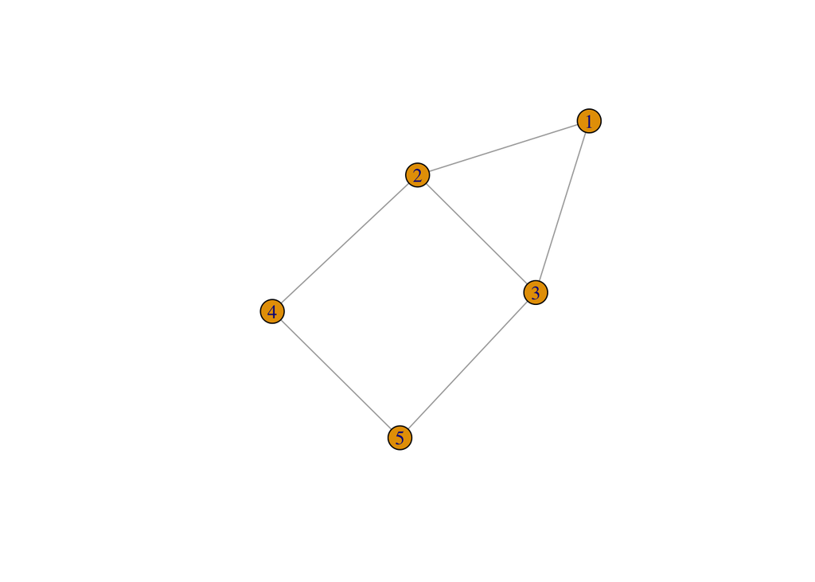

```r
h <- induced.subgraph(g, 1:5)
plot(h)
```

```r
str(h)
```

```
## IGRAPH UN-- 5 6 --
## + attr: name (v/c)
## + edges (vertex names):
## [1] 1--2 1--3 2--3 2--4 3--5 4--5
```

The same subgraph can also be created by just removing vertices 6 & 7 from `g`:

```r
h <- g - vertices(c(6,7))
```

If desired, `g` can be recovered in the following fashion:

```r
h <- h + vertices(c(6,7))
g <- h + edges(c(4,6), c(4,7), c(5,6), c(6,7))
```

`g` could also be restored with using the `graph.union` function:

```r
h1 <- h
h2 <- graph.formula(4-6, 4-7, 5-6, 6-7)
g <- graph.union(h1, h2)
```

## Decorating Network Graphs

Attributes are typically associated with the `$` operator.

For example, if we want to retrieve the `name` attribute of the object `dg` we can use `$name`:

```r
V(dg)$name
```

```
## [1] "Sam"  "Mary" "Tom"
```

We can also add attributes. For example, `gender` can be added as such:

```r
V(dg)$gender <- c("M", "F", "M")
```

If we want to add a color attribute . . . we can in a similar manner:

```r
V(g)$color <- "red"
```

Checking and adding for weights on edges:

```r
# Check for weights
is.weighted(g)
```

```
## [1] FALSE
```

```r
# Add weights by random uniform number generation
wg <- g
E(wg)$weight <- runif(ecount(wg))

# What does this look like?
E(wg)$weight
```

```
##  [1] 0.06996544 0.01069174 0.80590494 0.99284890 0.93445121 0.89044721
##  [7] 0.33623492 0.73102713 0.68906462 0.97013406
```

Identify the graph `g` by giving it a name:

```r
g$name <- "Toy Graph"
```

## Using Data Frames

The examples will be using the `lazega_dataset` from the `sand` library.

### Dataframe descriptions

`elist.lazega`: Edge list of collaborative working relationships

`v.attr.lazega`: Various vertex attribute variables

These dataframes can be used with an igraph object:

```r
# Construct the graph
g.lazega <- graph.data.frame(elist.lazega,
                             directed = "FALSE",
                             vertices = v.attr.lazega)

# Assign an identifier to the graph
g.lazega$name <- "Lazega Lawyers"
```

Explore the network:

```r
# Find the number of vertices
vcount(g.lazega)
```

```
## [1] 36
```

```r
# Find the number of edges
ecount(g.lazega)
```

```
## [1] 115
```

```r
# View the different features of the vertex attributes
list.vertex.attributes(g.lazega)
```

```
## [1] "name"      "Seniority" "Status"    "Gender"    "Office"    "Years"
## [7] "Age"       "Practice"  "School"
```

## Basic Graph Concepts

There are two types of graphs: `multigraphs` (which allow two edges per vertice pair) and `simplegraphs` which have been shown above.

Determine if a graph is a `simplegraph`:

```r
is.simple(g)
```

```
## [1] TRUE
```

Let’s create a `multigraph` and then recheck the status:

```r
# Add an edge that already exists to create two edges
mg <- g + edge(2,3)
str(mg) # Note the duplicate 3 and 2 in output
```

```
## IGRAPH UN-- 7 11 -- Toy Graph
## + attr: name (g/c), name (v/c), color (v/c)
## + edges (vertex names):
## 1 -- 2, 3
## 2 -- 1, 3, 3, 4
## 3 -- 1, 2, 2, 5
## 4 -- 2, 5, 6, 7
## 5 -- 3, 4, 6
## 6 -- 4, 5, 7
## 7 -- 4, 6
```

```r
is.simple(mg)
```

```
## [1] FALSE
```

Often, a `multigraph` is converted to a `weighted` graph by setting weights on its multiplicity of duplicate edges.

```r
# Setting one edge as a value of '1'
E(mg)$weight <- 1

# Converting multigraph into a simplegrapgh
wg2 <- simplify(mg)

# Due diligence
is.simple(wg2)
```

```
## [1] TRUE
```

```r
str(wg2)
```

```
## IGRAPH UNW- 7 10 -- Toy Graph
## + attr: name (g/c), name (v/c), color (v/c), weight (e/n)
## + edges (vertex names):
## 1 -- 2, 3
## 2 -- 1, 3, 4
## 3 -- 1, 2, 5
## 4 -- 2, 5, 6, 7
## 5 -- 3, 4, 6
## 6 -- 4, 5, 7
## 7 -- 4, 6
```

```r
# Note the weight of '2' refers back to the duplicate edge(2,3)
E(wg2)$weight
```

```
##  [1] 1 1 2 1 1 1 1 1 1 1
```

Use the `neighbors` function to find out the neighbors of a vertex. In this example we want to find all the neighbors of vertex `5`.

```r
neighbors(g, 5)
```

```
## + 3/7 vertices, named:
## [1] 3 4 6
```

Use the `degree` function to find out the degrees of each vertex on the graph `g`:

```r
degree(g)
```

```
## 1 2 3 4 5 6 7
## 2 3 3 4 3 3 2
```

For `digraphs`, we’ll have to use the `mode` parameter to determine whether we want to see `in` or `out` flowing edges.

```r
degree(dg, mode="in")
```

```
##  Sam Mary  Tom
##    0    2    2
```

```r
# OR

degree(dg, mode="out")
```

```
##  Sam Mary  Tom
##    2    1    1
```

Check if a graph is connected and view cluster descriptions:

```r
is.connected(g)
```

```
## [1] TRUE
```

```r
clusters(g)
```

```
## $membership
## 1 2 3 4 5 6 7
## 1 1 1 1 1 1 1
##
## $csize
## [1] 7
##
## $no
## [1] 1
```

Check if a graph is weakly connected and/or strongly connected:

```r
# Weak connected: every vertex is reachable through an undirected connection
is.connected(dg, mode="weak")
```

```
## [1] TRUE
```

```r
# Strongly connected: every vertex 'v' is reachable from every 'u' by a directed walk.
is.connected(dg, mode="strong")
```

```
## [1] FALSE
```

## Special Types of Graphs

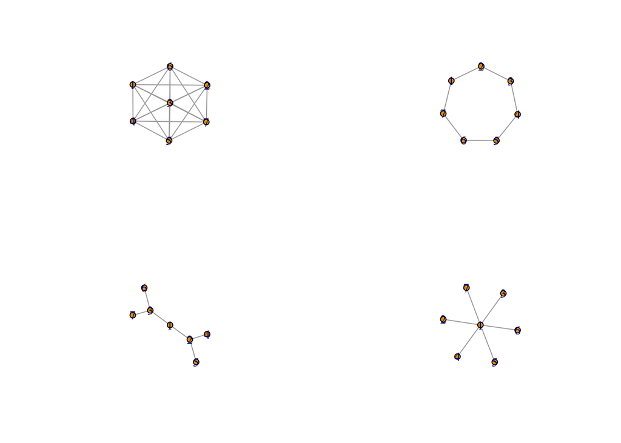

```r
g.full <- graph.full(7)
g.ring <- graph.ring(7)
g.tree <- graph.tree(7, children=2, mode="undirected")
g.star <- graph.star(7, mode="undirected")
par(mfrow=c(2,2))
plot(g.full) # Every vertex connected to every other vertex
plot(g.ring) # Every vertex has same degree
plot(g.tree) # A connected graph without cycles
plot(g.star) # One root and k leaves
```

Check if a graph is `directed acyclic`(directed graph that has no directed cycles):

```r
is.dag(dg)
```

```
## [1] FALSE
```

Bipartite graphs Example: `V1` as members and `V2` as organizaitons.

```r
# Studying the relationship between actors and movies
g.bip <- graph.formula(actor1:actor2:actor3,
                       movie1:movie2, actor1:actor2 - movie1,
                       actor2:actor3 - movie2)

# Set type:movie as TRUE and type:actor as FALSE
V(g.bip)$type <- grepl("^movie", V(g.bip)$name)
str(g.bip, v=T)
```

```
## IGRAPH UN-B 5 4 --
## + attr: name (v/c), type (v/l)
## + vertex attributes:
## |       name  type
## | [1] actor1 FALSE
## | [2] actor2 FALSE
## | [3] actor3 FALSE
## | [4] movie1  TRUE
## | [5] movie2  TRUE
## + edges (vertex names):
## [1] actor1--movie1 actor2--movie1 actor2--movie2 actor3--movie2
```

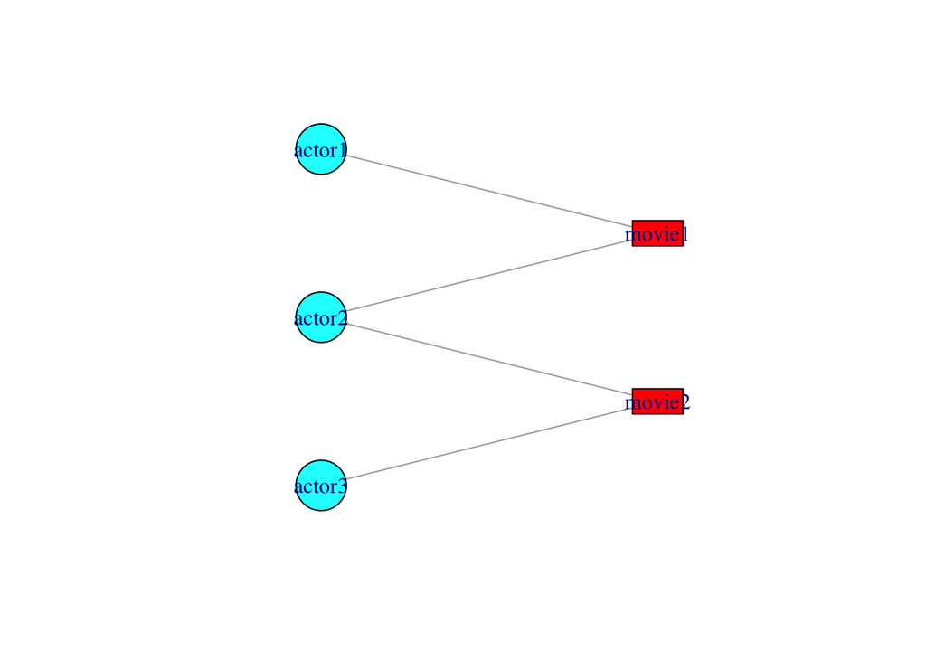

```r
# Plot g.bip
plot(g.bip, layout=-layout.bipartite(g.bip)[,2:1],
     vertex.size=30, vertex.shape=ifelse(V(g.bip)$type,
                                         "rectangle", "circle"),
     vertex.color=ifelse(V(g.bip)$type, "red", "cyan"))
```

Make bipartite projects:

```r
proj <- bipartite.projection(g.bip)
str(proj[[1]])
```

```
## IGRAPH UNW- 3 2 --
## + attr: name (v/c), weight (e/n)
## + edges (vertex names):
## [1] actor1--actor2 actor2--actor3
```

```r
str(proj[[2]])
```

```
## IGRAPH UNW- 2 1 --
## + attr: name (v/c), weight (e/n)
## + edge (vertex names):
## [1] movie1--movie2
```